# Pika Distribution and Population Trends at Niwot Ridge

https://github.com/ldye16/DyeFreedman_ENV872_EDA_FinalProject

Jacob Freedman and Logan Dye

# Rationale and Research Questions

The American Pika is a threatened small mammal endemic to alpine tundra habitat in the Rocky Mountains and Sierra Nevadas. Climate change is a growing threat worldwide, and is expected to have a particular impact on high elevation habitats. Pikas are sensitive to both temperature and changes in the water balance (impacted by seasonality of snowmelt), so climate change could undoubtedly threaten their long-term viability. In addition, as Pikas occupy habitat at the tops of mountain ridges, their possible migration either northward or to higher ridges would involve them crossing over lower elevation valleys. Their ability to do so is unknown, which makes their possibility of survival even murkier (National Wildlife Federation).

Niwot Ridge is one of the most heavily studied alpine areas in the Rocky Mountains. It is home to multiple research projects, as it is both a NEON and LTER Site. LTER researchers have gathered data on Pika demography and climate over the past 15-20 years. We used public datasets to answer multiple questions regarding trends in climate and Pika populations at Niwot Ridge.

1. Is temperature changing over time at Niwot Ridge?
2. Are Pika populations changing over time and is there a correlation between population changes and temperature changes?
3. Are Pika populations changing spatially over time? Are they seeking higher elevation sites?
4. An increase in zoonotic diseases is a well documented effect of warming temperatures. Is mite and flea prevalence in Pikas changing over time and with temperature?

# Dataset Information and Wrangling

Both climate and pika data was sourced from the Niwot Ridge LTER website. All datasets are for public use and are available here: https://nwt.lternet.edu/data-catalog Significant wrangling was required to answer the research questions. The general process is explained below for each research question.

Temperature changes over time:

Climate data was available from 2000 to 2018, but 2008 to 2018 were selected as this time frame overlapped with the available pika data. The dataset contained the site and device names, daily min, max, and avg air temperature, relative humidity, barometric pressure, wind speed/direction, solar radiation and soil temperature. We then used the package “zoo” to interpolate NA values in the temperature data.

Pika population changes over time and in relation to temperature:

Pika data was available from 2008 to 2020, but 2008 to 2018 were selected as this time frame overlapped with the available climate data. The dataset contained the site, data, slope aspect, location of capture, identification information, demography data, biological samples collected and parasite presence. In order to estimate population over time, annual pika captures were identified at Niwot Ridge. This required eliminating recaptures within the same year. Captures without a “tag type”, meaning that they were not tagged and there was insufficient information to rule it out as a recapture, were eliminated. Second, observations where the tag type was recorded, but none of the tag information (ear tag color or number code) was recorded, were eliminated. Finally, the dataset was split into separate datasets for each year and the number of unique tag IDs (PikaID) was found to derive annual counts.

To prepare for our temperature and pika abundance regressions, it was necessary to calculate mean annual temperature values. The interpolated temperature dataset was grouped by year and then summarized by average daily temperature to calculate annual means. A column of “year number” (e.g. 1 = 2008) was also generated to run both regressions.

Pika spatial distribution changes:

To assess spatial changes, observations without spatial attributes (easting, northing) were eliminated. Mean annual pika locations were determined by summarizing the easting and northing columns. Both individual and mean annual locations were converted to spatial dataframes using the NAD83 Zone 13N projected coordinate system.

Parasite Data:

To determine if there was a change in parasite abundance over time and with changing temperatures, flea and ear mite data was isolated from the overall pika demography data. The parasite data included flea observations, fleas sampled, ear mite observations, and ear mites sampled. For both flea observations and fleas sampled, the recorded value was the number of fleas either observed on or sampled on an individual pika. For ear mites sampled, the recorded values were binary. A “0” was recorded when a pika was not sampled for ear mites, and a “1” was recorded when a pika was sampled for ear mites. For ear mites observed, the data was categorical. The categories were “N” for none, “L” for low density, “M” for medium density, “H” for high density, “NA” for individuals whose data was not recorded in the main trapping notebook, and “NS” for Pikas who were not sampled for mites in this way. There are also a few instances of either a “0” or a “1” being recorded and a single recording of “N?”.

Once we had isolated the flea and ear mite data from the demography data, we split the dataframe into two, one with only flea data and one with only ear mite data.

For the flea data, we grouped by PikaID to isolate individual pikas that were recaptured in a given year. The data was split by year to find the mean value of fleas sampled and fleas observed per pika for each year. The single-year dataframes were then merged to create one dataframe with the average number of fleas observed and sampled per pika per year.

The same methodology was used to wrangle the mite data. However, since the data was binary, either “0” or “1”, the resulting ear mite sampled column represented a proportion of captured pikas sampled for ear mites. Generally, if ear mites were observed on a pika, they were sampled. Thus, the proportion of pikas sampled for ear mites represents the proportion of total pikas captured in a given year with ear mites present.

For ear mite observed data, a different wrangling technique was used to account for the categorical data. The NA, NS, 0, 1, and N? observations were eliminated and observations with ear mite data were retained: N, L, M, and H. The ear mite densities were grouped by year and summarized to obtain an annual account for each density category. To account for the different number of pika captures each year, the data was converted to an annual proportion of each mite density.

In the final step, the flea and mite dataframes were joined into one final parasite dataframe. The final parasite dataframe was then joined to the climate dataframe and a column of “year number” (e.g. 1 = 2008) was generated to prepare for analysis.

# Exploratory Analysis

To initially explore the data, two simple plots were created with linear trendlines. Mean average temperature from 2000-2018 (Figure 1) and pika captures per year from 2008-2020 (Figure 2) demonstrate some promising patterns. Temperature appears to be increasing over time while pika population appears to be in decline.

```
## [1] "factor"
```

```
## [1] "Date"
```

```
## [1] "factor"
```

```
## [1] "Date"
```

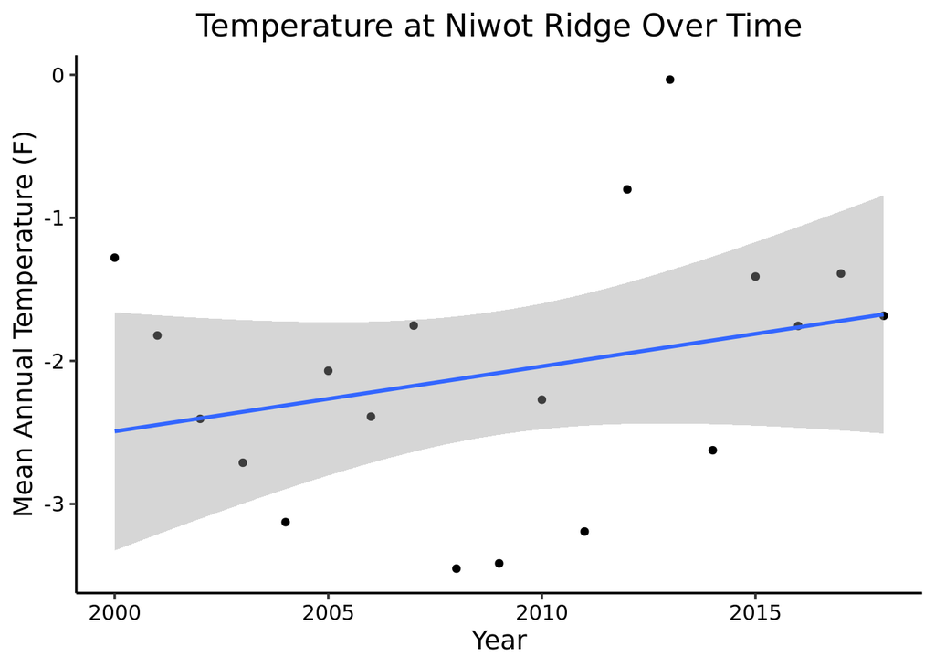

Scatterplot of mean annual temperature at Niwot Ridge from 2000 to 2018.

```
## [1] 40
```

```
## [1] 29
```

```
## [1] 43
```

```
## [1] 24
```

```
## [1] 30
```

```
## [1] 28
```

```
## [1] 14
```

```
## [1] 40
```

```
## [1] 24
```

```
## [1] 21
```

```
## [1] 18
```

```
## [1] 31
```

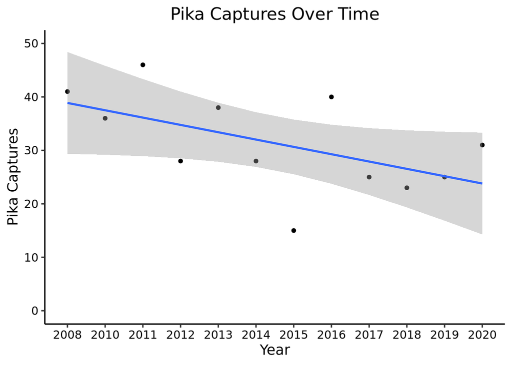

Scatterplot of total annual pika captures at Niwot Ridge from 2008 to 2020.

# Analysis

## Question 1: Is temperature changing over time at Niwot Ridge?

A time series of daily average temperature was conducted from 2008 to 2018 to assess temperature changes over time. Temperature changed significantly at Niwot Ridge (Seasonal Mann-Kendall, p-value = 6.133e-11). This is clear when examining the decomposed temperature data (Figure 3), which despite the expected seasonality displays a trend of increasing temperature. A plot of mean annual temperature also visually reinforces these results (Figure 4).

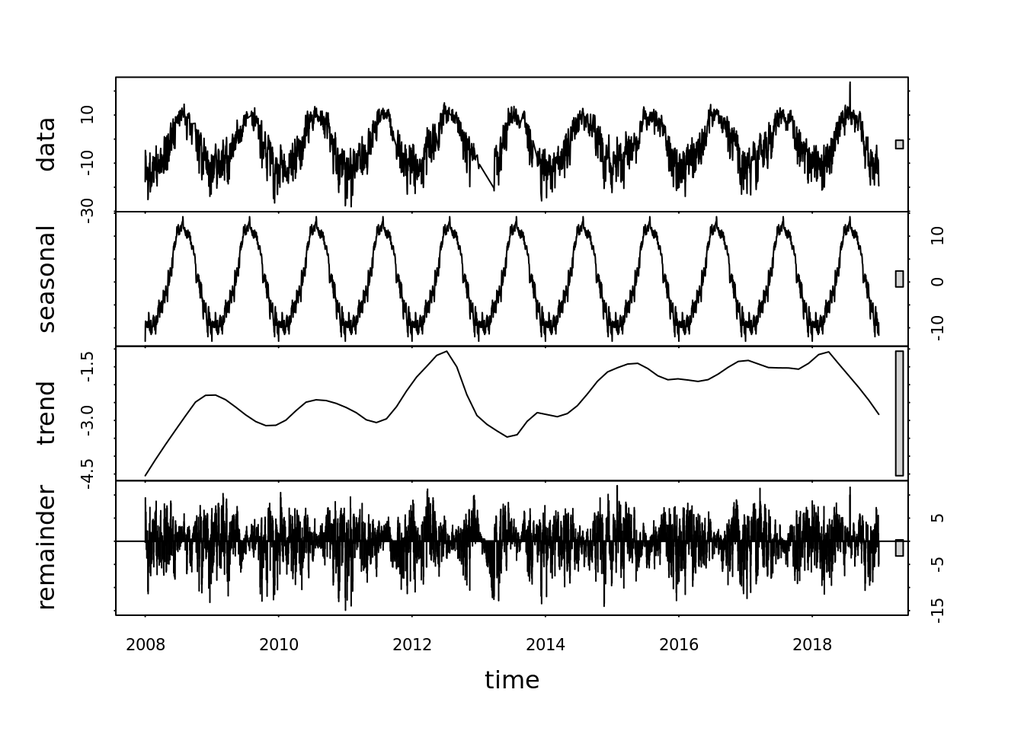

Decomposed time series plot showing seasonal and overall temperature trends at Niwot Ridge from 2008 to 2018.

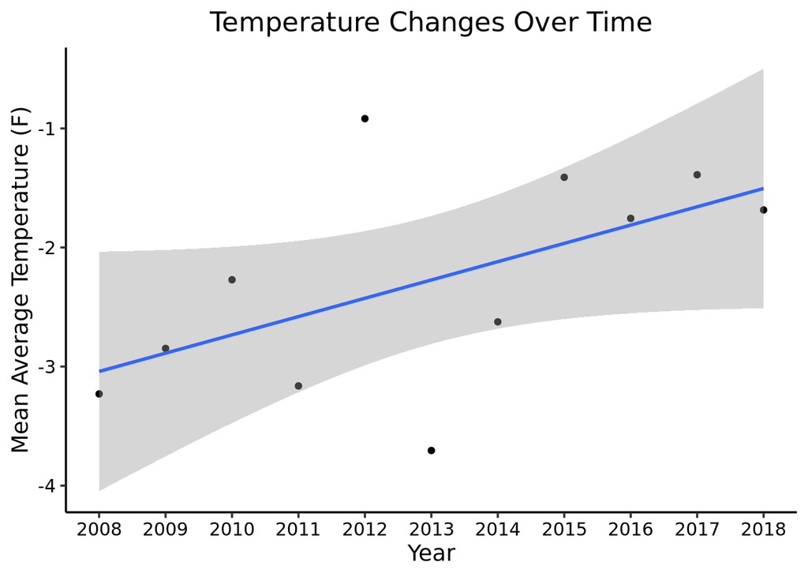

Scatterplot of mean annual temperature at Niwot Ridge from 2008 to 2018.

## Question 2: Are Pika populations changing over time and is there a correlation between population changes and temperature changes?

Linear regressions were conducted to analyze pika populations over time and in relation to changing temperature. Annual pika populations did not change significantly from 2008 to 2020 (Linear Model, F = 2.98, df = 10, Adjusted R-squared = 0.1525, p-value = 0.115). However, the general population trend appears to be decreasing (Figure 5) and it was found that populations did decrease significantly in response to higher temperatures (Linear Model, F = 6.396, df = 8, Adjusted R-squared = 0.3748, p-value = 0.0353, Figure 6).

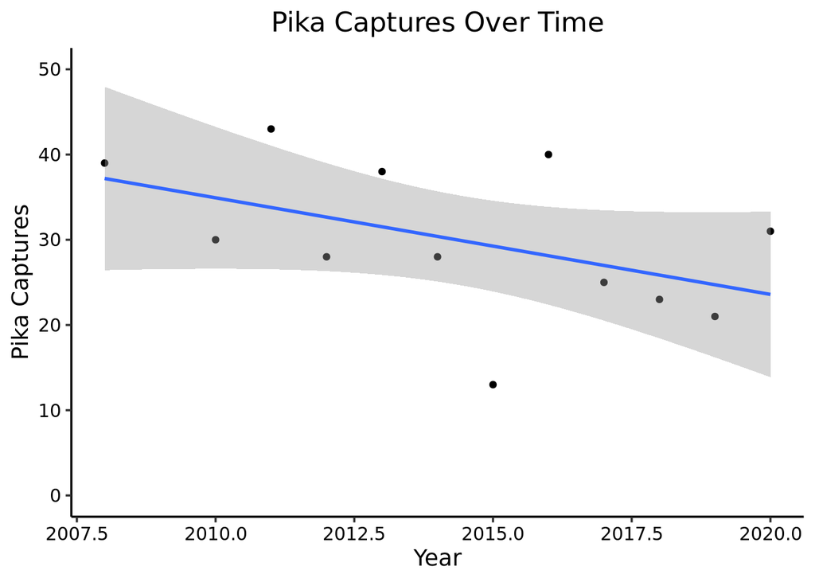

Scatterplot of total annual pika captures at Niwot Ridge from 2008 to 2020.

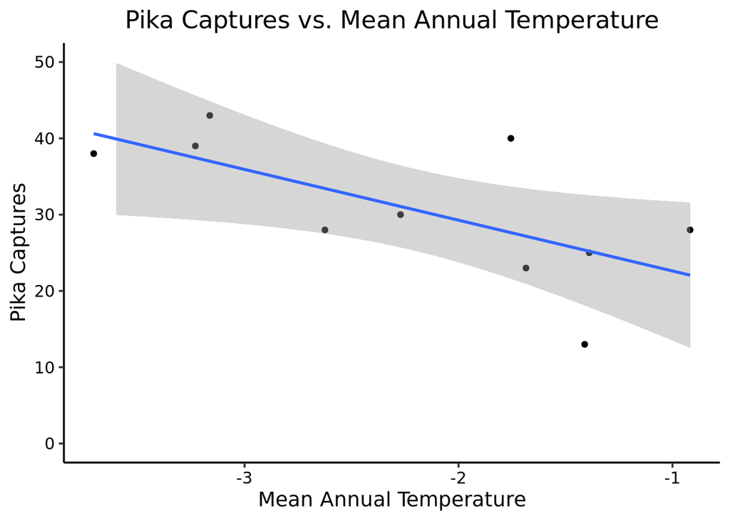

Scatterplot of annual pika captures and mean temperature at Niwot Ridge from 2008 to 2018.

## Question 3: Are Pika populations changing spatially over time? Are they seeking higher elevation sites?

Spatial changes in pika population were estimated by calculating and plotting the mean annual capture location. Figure 7 shows the mean capture locations from 2008 to 2020, and Figure 8 shows all captures to help better visualize the study area. There are three sampling sites (Mitchell Lake to the North - 11,044 feet, Long Lake in the center - 10,675 feet, West Knoll to the South - 11,653 feet). There does not appear to be a clear pattern in distribution changes, as the mean capture location changes seemingly randomly in a northward or southward from year to year. In particular, the mean annual capture locations for 2008 and 2020 (the entire timeframe of the data) are nearly identical. Therefore, it appears that pika are not favoring higher elevation ridges in response to climate change. Note: We apologize for the label overlap, but points can be distinguished at a higher magnification.

[interactive chart not shown]

Mean annual pika capture locations from 2008 to 2020.

[interactive chart not shown]

All pika capture locations from 2008 to 2020. The three sampling sites were Mitchell Lake to the North - 11,044 feet, Long Lake in the center - 10,675 feet, and West Knoll to the South - 11,653 feet.

## Question 4: One well documented effect of warming temperatures is an increase in zoonotic diseases. Is mite and flea prevalence in Pikas changing over time and with temperature?

Linear regressions were run on yearly flea observed, flea sampled, and ear mite sampled data over time and temperature. The regressions found no significance for flea observed data over time (linear model, F = 0.6691, df = 9, Adjusted R-Square = -0.03422, p-value = 0.4345) and temperature (linear model, F = 0.9955, df = 7, Adjusted R-Square = -0.0005629, p-value = 0.3516)(Figure 9).

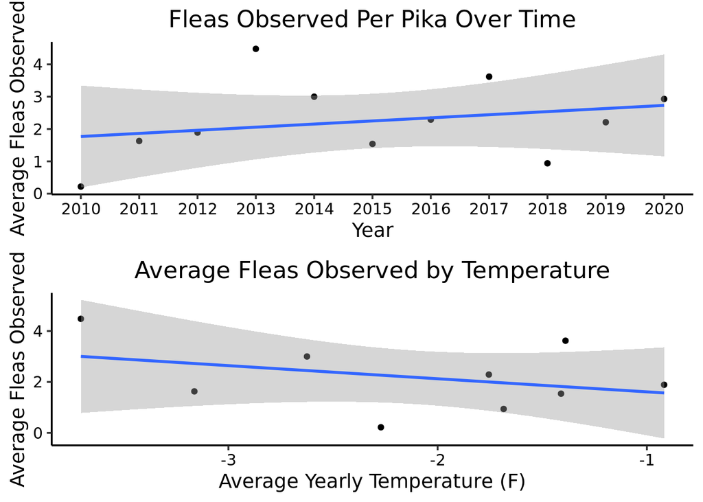

Average number of fleas observed per year per pika over time (top) and temperature (bottom).

Likewise, when regressions were run on the number of fleas sampled per pika over time (linear model, F = 1.112, df = 10, Adjusted R-Square = 0.01005, p-value = 0.3165) and temperature (linear model, F = 0.3773, df = 8, Adjusted R-Square = -0.07434, p-value = 0.5561), no significant trends were found (Figure 10).

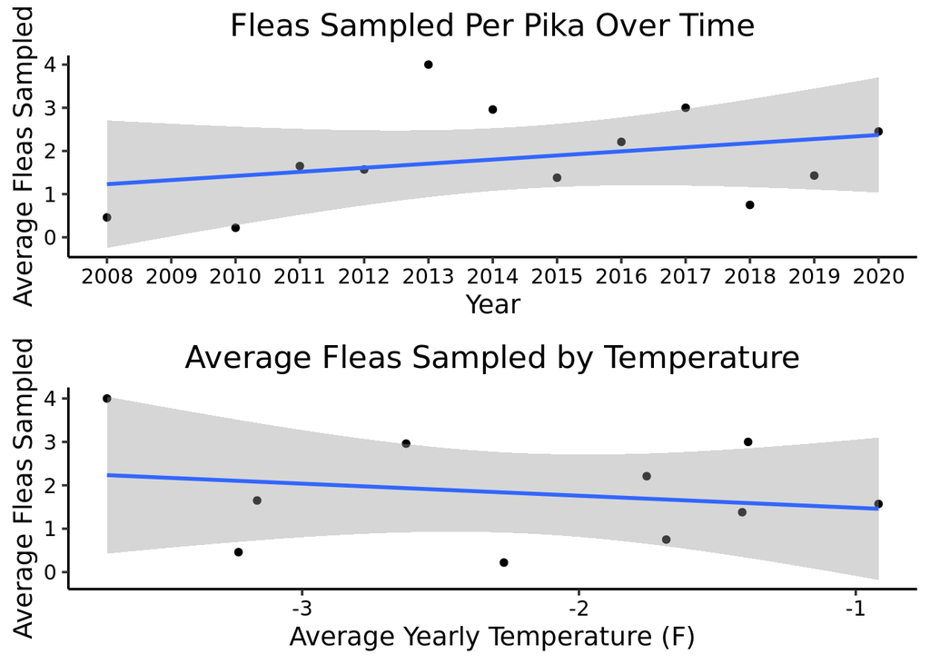

Average number of fleas sampled per year per pika over time (top) and temperature (bottom).

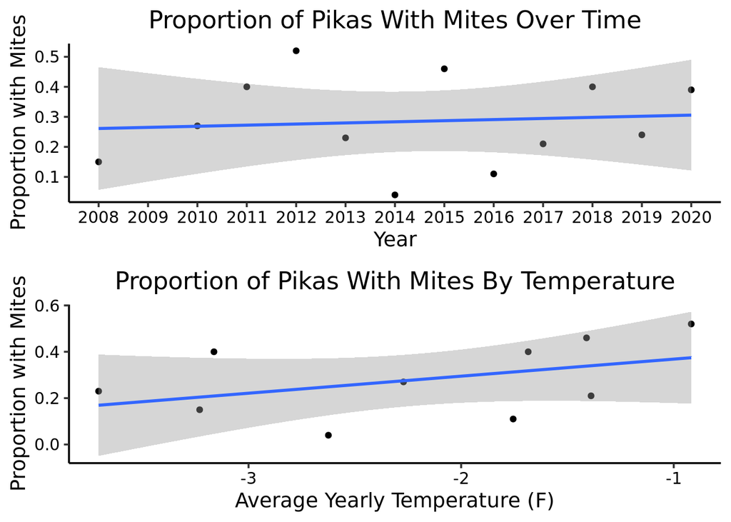

Proportion of pikas with mites per year over time (top) and temperature (bottom).

While no clear patterns were found for any of our tested variables, some plots reveal the expected general trends. Fleas sampled, fleas observed, and mites sampled visually increased over time (Figure 9,10,11). However, when compared to temperature data, only the proportion of mites present on captured pikas increased with increasing temperature. The flea data trend lines decreased with increasing temperature. As shown in figure 12, the ear mite observed categories had no perceivable pattern that would indicate a correlation over time.

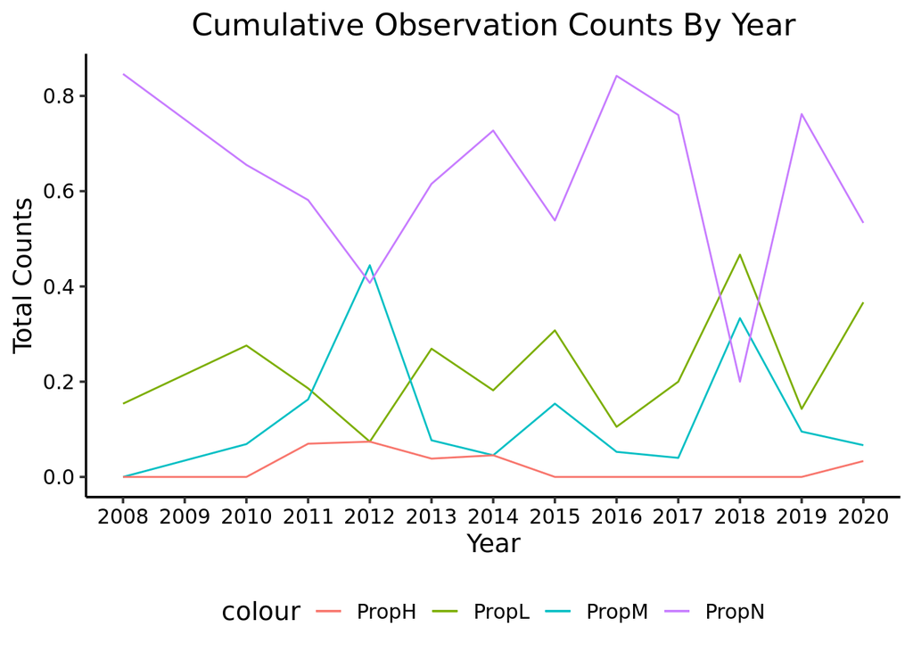

Proportion of pikas with given mite density (PropN = None, PropL = Low, PropM = Medium, PropH = High) over time.

# Summary and Conclusions

No parasitic data had a significant correlation when regressions were run over time and temperature. This analysis indicates that, while it is estimated that increased temperatures over time will lead to an increase of parasites, this trend has not actualized over the last ten years within the pika population sampled at NIWOT Ridge.

# References

American Pika. National Wildlife Federation. (n.d.). Retrieved December 8, 2022, from https://www.nwf.org/Educational-Resources/Wildlife-Guide/Mammals/American-Pika#:~:text=American%20pikas%20are%20small%2C%20rodent,to%20camouflage%20them%20among%20rocks.